# Data Visualization Tutorial

### Adding lines to the scatterplots

Two most common trend lines added to a scatterplots are the “best fit” straight line and the “lowess” smoother line.

#### base graphics

The best fit line (in blue) gets added by using the `abline()` function wrapped around the linear model function `lm()`. Note it uses the same model notation syntax and the `data=` statement as the `plot()` function does. The lowess line is added using the `lines()` function, but the `lowess()` function itself doesn’t allow for the `data=` statement so we have to use `$` sign notation.

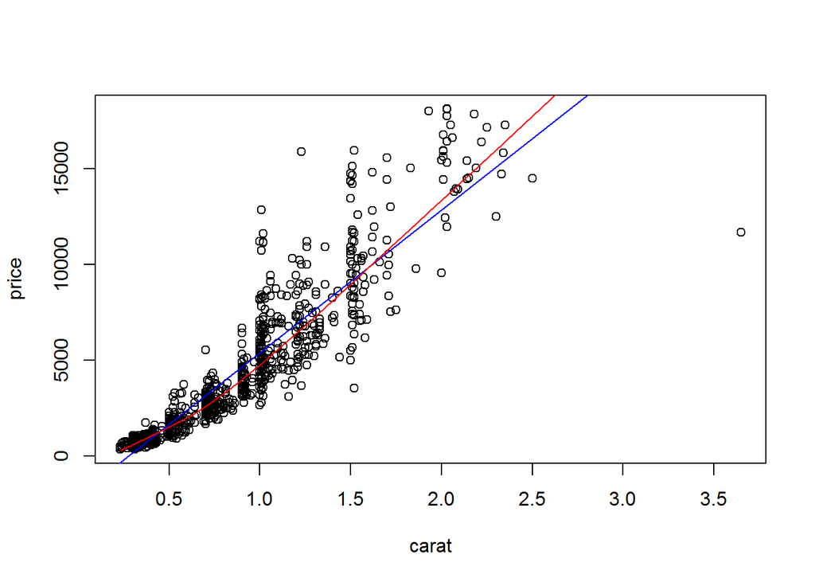

```r
plot(price~carat, data=dsmall)
abline(lm(price~carat, data=dsmall), col="blue")
lines(lowess(dsmall$price~dsmall$carat), col="red")
```

#### ggplot

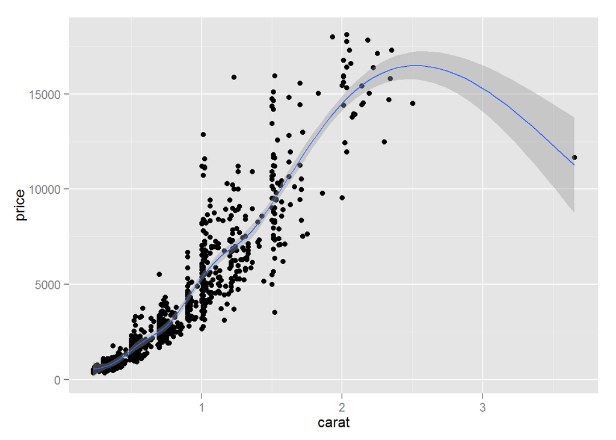

```r
qplot(x=carat, y=price, data=dsmall, geom=c("point", "smooth"))
```

Here the point-wise confidence interval is shown in grey. If you want to turn the confidence interval off, use `se=FALSE`. Also notice that the smoothing geom uses a different function or window than the `lowess` function used in base graphics. Here it is again using the `ggplot` plotting function and adding the `geom_smooth()` function and plotting the `lm` (linear model) line instead of the lowess smoothing algorithm.

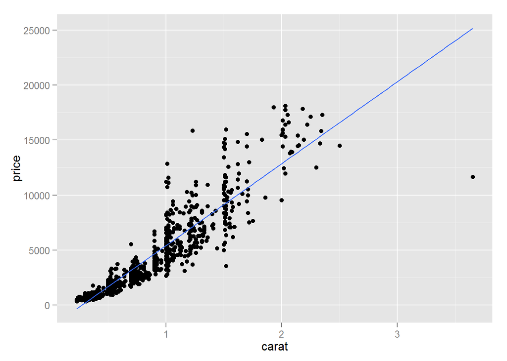

```r
ggplot(dsmall, aes(x=carat, y=price)) + geom_point() + geom_smooth(se=FALSE, method="lm")
```

# Two numerical and one categorical

And lastly let’s look back at how we can play with scatterplots of using a third categorical variable (using `ggplot2` only). We can color the points by cut,

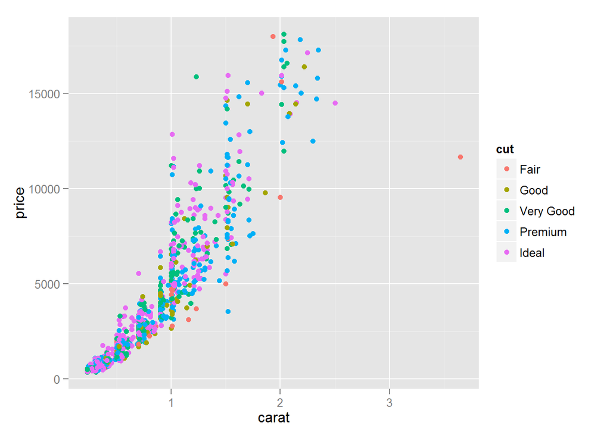

```r
ggplot(dsmall, aes(x=carat, y=price, color=cut)) + geom_point()
```

We could add a smoothing lowess line for each cut separately,

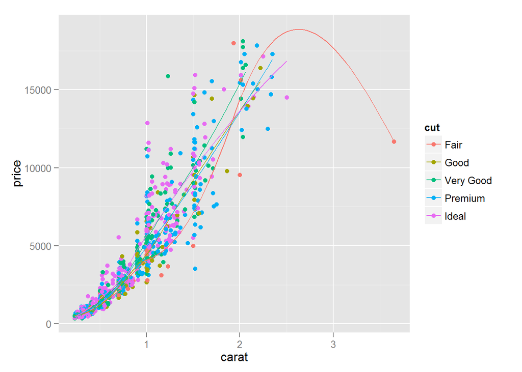

```r
ggplot(dsmall, aes(x=carat, y=price, color=cut)) + geom_point() + geom_smooth(se=FALSE)
```

We could change the color by clarity, and shape by cut.

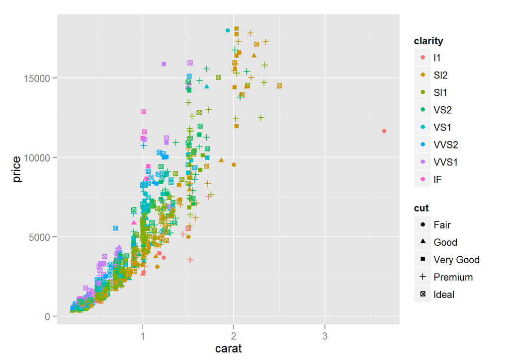

```r
ggplot(dsmall, aes(x=carat, y=price, color=clarity, shape=cut)) + geom_point()
```

That’s pretty hard to read. So note that just because you **can** change an aestetic, doesn’t mean you should. And just because you can plot things on the same axis, doesn’t mean you have to.

# One numeric and one categorical

How does the color of a diamond affect the carat?

### Stripchart

These plots still only work well for small amounts of data, or if you’re plotting summary statitics like the mean. This looks like model notation, but notice that it plots the groups on the y axis and carat on the x.

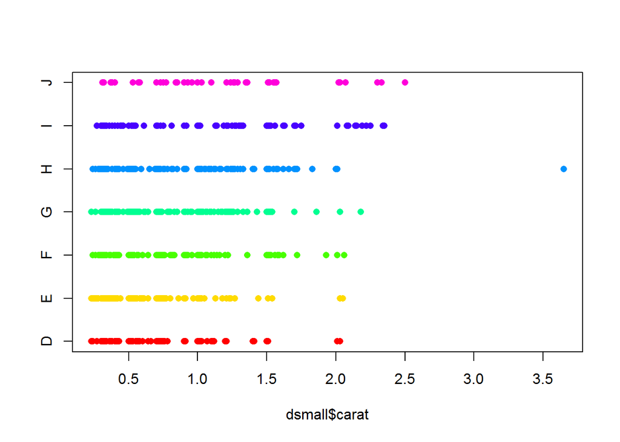

```r
stripchart(dsmall$carat ~ dsmall$color, pch=16, col=rainbow(7))
```

Note that the number that goes into the `rainbow()` argumnet is the number of categories that are to be colored. If you put a lower number here the colors will recycle. So you could end up with 2 red strips etc.

#### ggplot

Here is an example using `qplot` and one with `ggplot`.

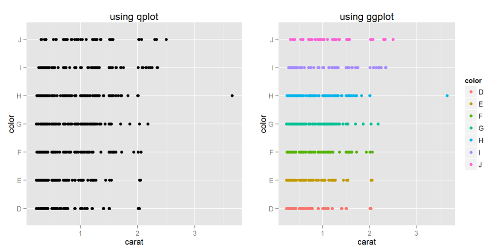

```r
a <- qplot(x=carat, y=color, data=dsmall, geom="point", main="using qplot")
b <- ggplot(dsmall, aes(x=carat, y=color, col=color)) + geom_point() + ggtitle("using ggplot")
grid.arrange(a, b, ncol=2)
```

### Grouped boxplots

#### base graphics

Base graphics plots grouped boxplots with also just the addition of a twiddle `~`. Another example of where model notation works.

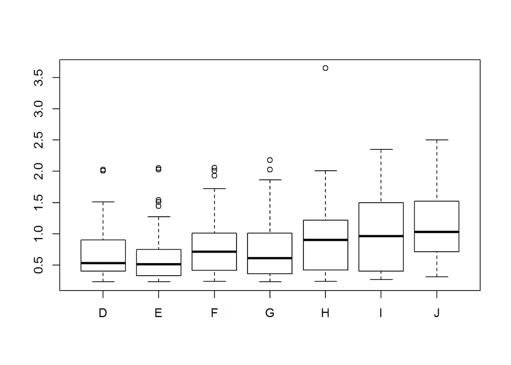

```r
boxplot(carat~color, data=dsmall)
```

#### ggplot

A simple addition, just define your x and y accordingly.

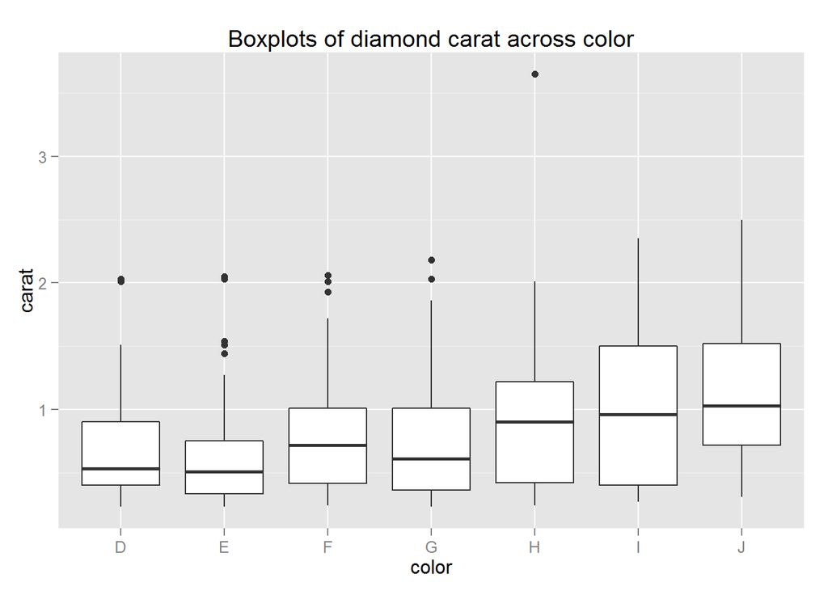

```r
qplot(x=color, y=carat, data=dsmall, geom="boxplot", main="Boxplots of diamond carat across color")
```

But what about the plotting colors man?

Add the variable you want to control the colors as an argument to color (for the outline) or fill. Using ggplot you have to add these options into the `aes()` statement.

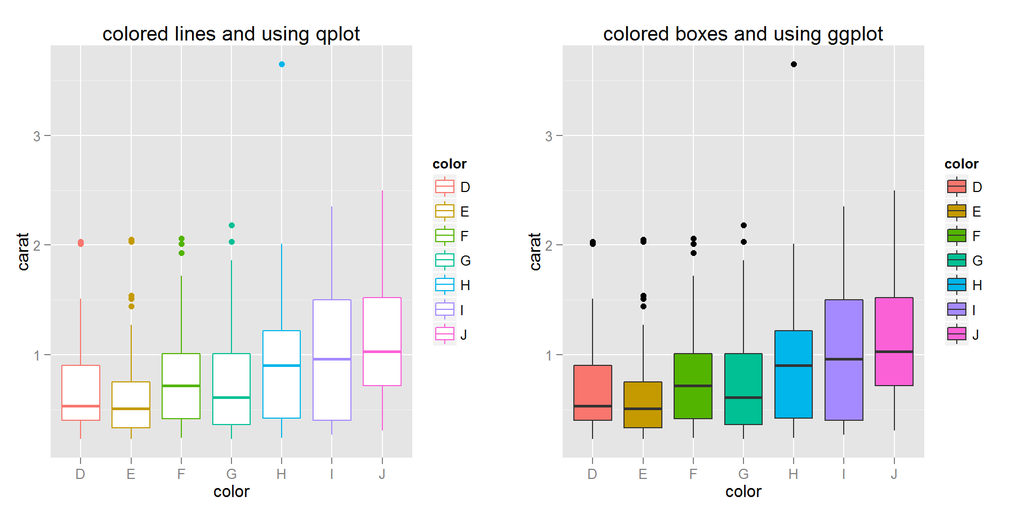

```r
cl <- qplot(x=color, y=carat, data=dsmall, geom="boxplot", color=color,
            main="colored lines and using qplot")
ct <- ggplot(dsmall, aes(x=color, y=carat, fill=color)) + geom_boxplot() +
             ggtitle("colored boxes and using ggplot")
grid.arrange(cl, ct, ncol=2)
```

### Grouped histograms

#### base graphics

There is no easy way to create grouped histograms in base graphics we will skip it.

#### ggplot

By default ggplot wants to overlay all plots on the same grid. This doesn’t look to good with histograms. Instead you can overlay density plots

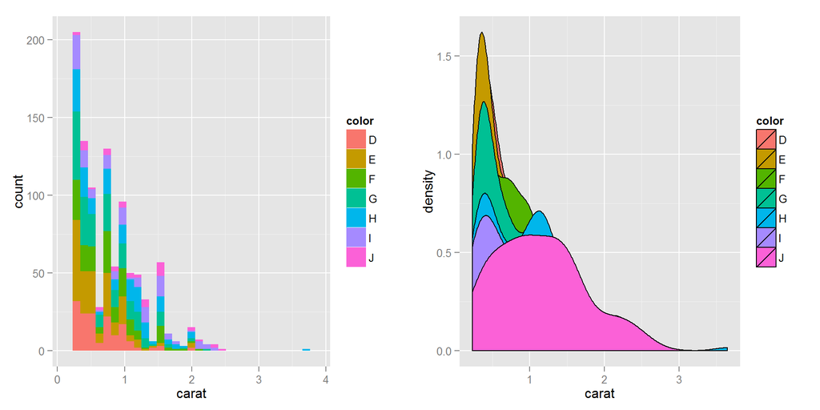

```r
a <- qplot(x=carat, data=dsmall, geom="histogram", fill=color)
b <- qplot(x=carat, data=dsmall, geom="density", fill=color)
grid.arrange(a,b, ncol=2)
```

The solid fills are still difficult to read, so we can either turn down the alpha (turn up the transparency) or only color the lines and not the fill.

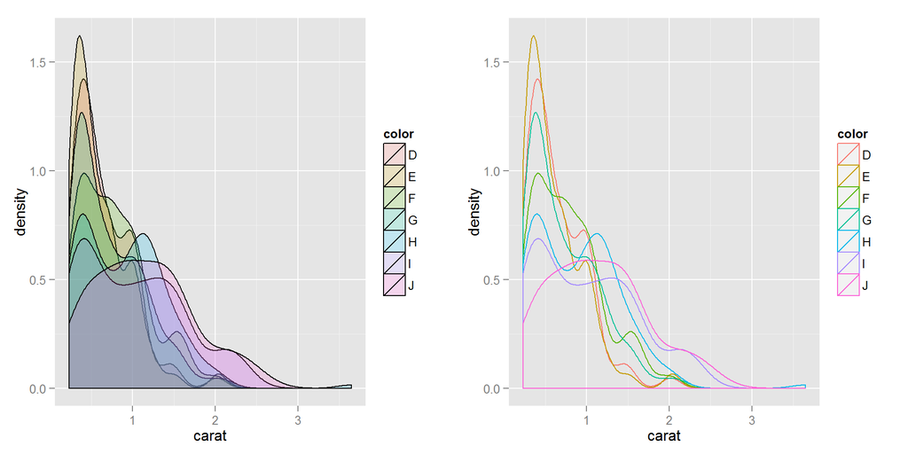

```r
c <- ggplot(dsmall, aes(x=carat, fill=color)) + geom_density(alpha=.2)
d <- ggplot(dsmall, aes(x=carat, col=color)) + geom_density()
grid.arrange(c,d, ncol=2)
```

But what if we **really** wanted to compare histograms?

# Faceting / paneling

ggplot introduces yet another term called `faceting`. The definition is *a particular aspect or feature of something*, or *one side of something many-sided, especially of a cut gem*. Basically instead of plotting the grouped graphics on the same plotting area, we let each group have it’s own plot, or facet.

Using `qplot` is a nice default. It is important to compare distriubtions across groups on the same scale, and our eyes can compare items vertically better than horizontally.

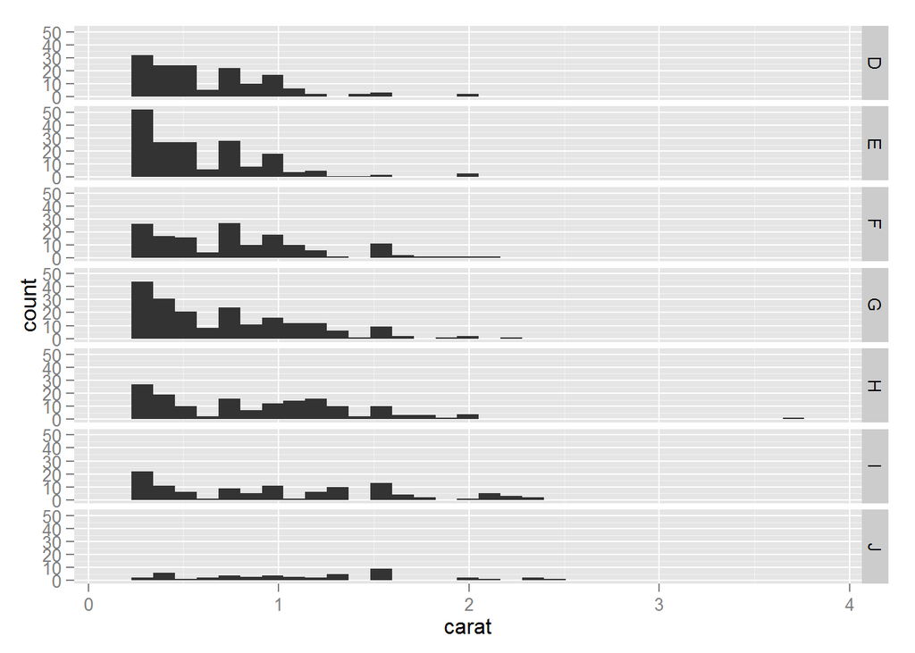

```r
qplot(x=carat, data=dsmall, geom="histogram", facets=color ~.)
```

If we use the `ggplot` function, after adding a `geom_histogram` we add a `facet_wrap()` and specify that we want to wrap on the color group. Note the twiddle in front of color and no period.

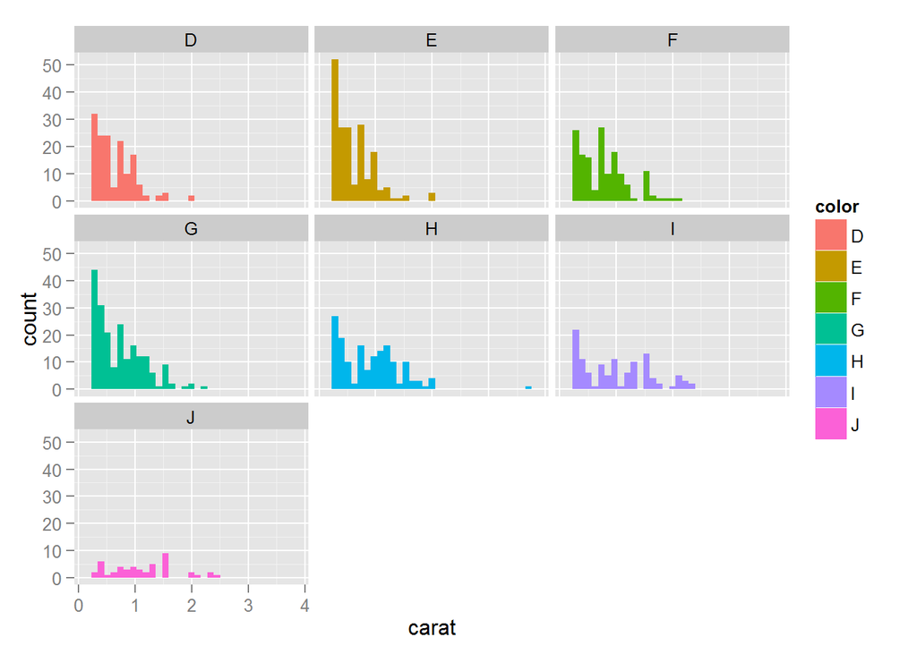

```r
ggplot(dsmall, aes(x=carat, fill=color)) + geom_histogram() + facet_wrap(~color)
```

The grid placement can be semi-controlled by using the `ncol` argument in the facet_wrap() statement.

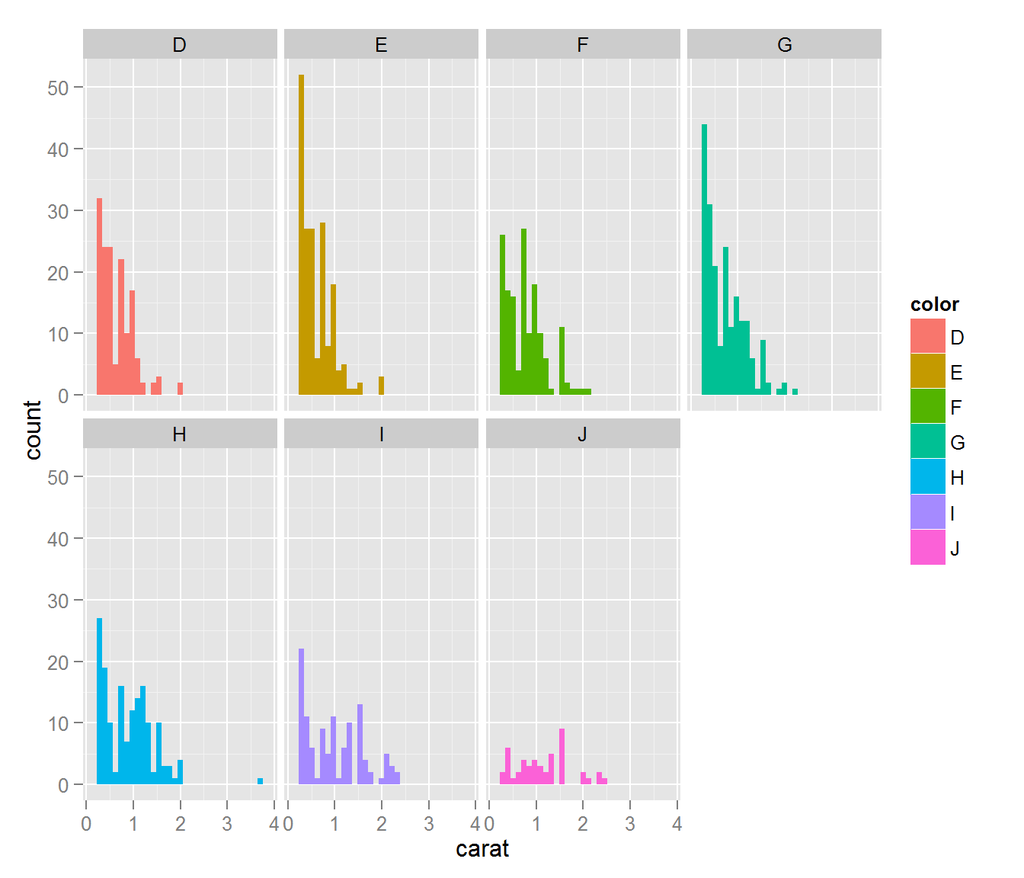

```r
ggplot(dsmall, aes(x=carat, fill=color)) + geom_histogram() + facet_wrap(~color, ncol=4)
```

But what did i just say about not being able to compare distributions easily when they’re horizontal? No problem, use `facet_grid()` instead. Look at the difference when the `~.` is on the left, and right hand side of the paneling variable.

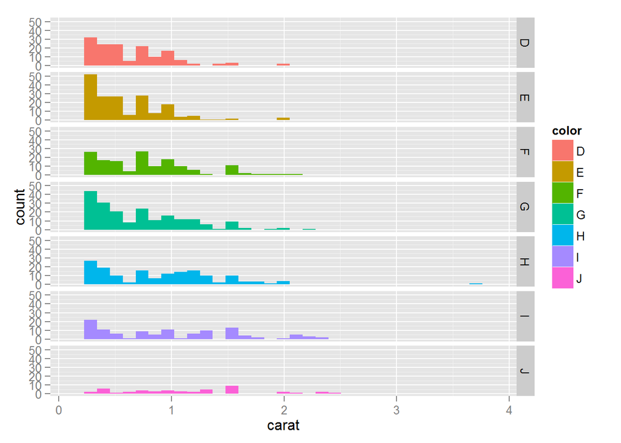

```r
ggplot(dsmall, aes(x=carat, fill=color)) + geom_histogram() + facet_grid(color~.)
```

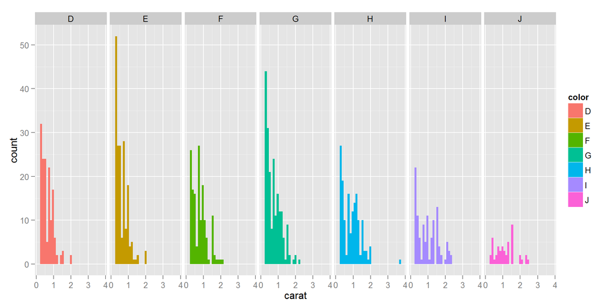

```r
ggplot(dsmall, aes(x=carat, fill=color)) + geom_histogram() + facet_grid(.~color)
```

## Paneling on two variables

Who says we’re stuck with only faceting on one variable?

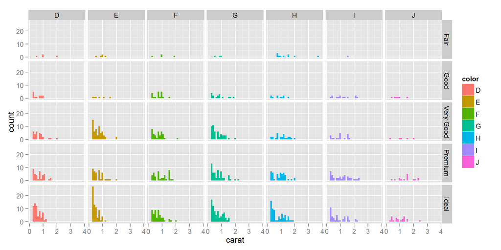

```r
ggplot(dsmall, aes(x=carat, fill=color)) + geom_histogram() + facet_grid(cut~color)
```

How about plotting price against caret, for all combinations of color and clarity, with the points further separated by cut?

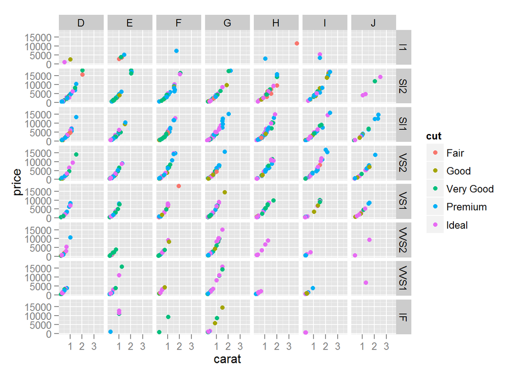

```r
ggplot(dsmall, aes(x=carat, y=price, color=cut)) + geom_point() + facet_grid(clarity~color)
```

Before you share your plot with any other eyes, always take a step back and try to expain what it is telling you. If you have to take more than a minute to get to the point then it may be too complex and simpler graphics are likely warranted.

# Additional Resources

- R Graphics Cookbook: http://www.cookbook-r.com/Graphs/ or http://amzn.com/1449316956 **Highly Highly Recommended**
- Quick-R: [Basic Graphs](http://www.statmethods.net/graphs/index.html)
- Quick-R: [ggplot2](http://www.statmethods.net/advgraphs/ggplot2.html)
- Books
  - ggplot2 http://ggplot2.org/book/ or http://amzn.com/0387981403
  - qplot http://ggplot2.org/book/qplot.pdf
- ggplot2 mailing list http://groups.google.com/group/ggplot2
- stackoverflow http://stackoverflow.com/tags/ggplot2